# Part Two: Exploration of `northwind.sqlite` Database

In this document we'll be exploring the performance of the nine employees listed in the *`northwind.sqlite`* database. The *'northwind'* database is sample database created by Microsoft for let's say, abc company having business model related to food and beverages distribution. This database contains details for the products, categories, customers, orders, inventory, purchasing, suppliers, shipping and also employees!

For this Project, we'll explore more on employees based on below criteria such as:

- how much quantity they sold
- products of total amount sold
- how many products sold
- employee's regional performance
- employee's overall performance over the time,
- employee's strengths, and weaknesses.

To get started, first we need to import below libraries.

1. import sqlite3 - This module allows accessing the sqlite3 database using a nonstandard variant of the SQL query language.
2. import pandas as pd - pandas is an open source data analysis library built on top of the Python programming language.
3. import numpy as np - NumPy is the fundamental package for scientific computing in Python.
4. from collections import Counter - `Collection` module implements specialized container datatypes and `Counter` dict subclass for counting hashable objects
5. import matplotlib.pyplot as plt - This is a collection of functions that make matplotlib work like MATLAB. Each pyplot function makes some change to a figure
6. import seaborn as sns - `Seaborn` is a library for making statistical graphics in Python. It builds on top of `matplotlib` and integrates closely with `pandas` data structures.

Now, let's deep dive into database tables and take a look at the data provided to get a meaningful insights from a business model.

```python
import sqlite3
import pandas as pd
import numpy as np

#Using connect function, let's connect to sqlite3 database.
con = sqlite3.connect("northwind.sqlite")
```

**First we will begin with looking into all our tables available in this database.**

```python
pd.read_sql("SELECT * FROM sqlite_schema WHERE type = 'table' ORDER BY name", con)
```

|  | type | name | tbl_name | rootpage | sql |
| --- | --- | --- | --- | --- | --- |
| 0 | table | Categories | Categories | 2 | CREATE TABLE [Categories]\n( [CategoryID]... |
| 1 | table | CustomerCustomerDemo | CustomerCustomerDemo | 28 | CREATE TABLE [CustomerCustomerDemo](\n [Cust... |
| 2 | table | CustomerDemographics | CustomerDemographics | 30 | CREATE TABLE [CustomerDemographics](\n [Cust... |
| 3 | table | Customers | Customers | 32 | CREATE TABLE [Customers]\n( [CustomerID] ... |
| 4 | table | EmployeeTerritories | EmployeeTerritories | 68 | CREATE TABLE [EmployeeTerritories](\n [Emplo... |
| 5 | table | Employees | Employees | 38 | CREATE TABLE [Employees]\n( [EmployeeID] ... |
| 6 | table | Order Details | Order Details | 70 | CREATE TABLE [Order Details](\n [OrderID]INT... |
| 7 | table | Orders | Orders | 92 | CREATE TABLE [Orders](\n [OrderID]INTEGER NO... |
| 8 | table | Products | Products | 128 | CREATE TABLE [Products](\n [ProductID]INTEGE... |
| 9 | table | Regions | Regions | 132 | CREATE TABLE [Regions](\n [RegionID]INTEGER ... |
| 10 | table | Shippers | Shippers | 133 | CREATE TABLE [Shippers](\n [ShipperID]INTEGE... |
| 11 | table | Suppliers | Suppliers | 134 | CREATE TABLE [Suppliers](\n [SupplierID]INTE... |
| 12 | table | Territories | Territories | 135 | CREATE TABLE [Territories](\n [TerritoryID]T... |
| 13 | table | sql3 | sql3 | 139 | CREATE TABLE sql3(EmployeeID INT,RegionDescrip... |
| 14 | table | sql4 | sql4 | 140 | CREATE TABLE sql4(EmployeeID INT,RegionDescrip... |
| 15 | table | sqlite_sequence | sqlite_sequence | 3 | CREATE TABLE sqlite_sequence(name,seq) |

Since we are interested in Employees, let's get to know them.

```python
emps = pd.read_sql("SELECT EmployeeID,FirstName,LastName, BirthDate,HireDate, City,Country,Title,ReportsTo FROM Employees", con)
emps
```

|  | EmployeeID | FirstName | LastName | BirthDate | HireDate | City | Country | Title | ReportsTo |
| --- | --- | --- | --- | --- | --- | --- | --- | --- | --- |
| 0 | 1 | Nancy | Davolio | 1948-12-08 | 1992-05-01 | Seattle | USA | Sales Representative | 2.0 |
| 1 | 2 | Andrew | Fuller | 1952-02-19 | 1992-08-14 | Tacoma | USA | Vice President, Sales | NaN |
| 2 | 3 | Janet | Leverling | 1963-08-30 | 1992-04-01 | Kirkland | USA | Sales Representative | 2.0 |
| 3 | 4 | Margaret | Peacock | 1937-09-19 | 1993-05-03 | Redmond | USA | Sales Representative | 2.0 |
| 4 | 5 | Steven | Buchanan | 1955-03-04 | 1993-10-17 | London | UK | Sales Manager | 2.0 |
| 5 | 6 | Michael | Suyama | 1963-07-02 | 1993-10-17 | London | UK | Sales Representative | 5.0 |
| 6 | 7 | Robert | King | 1960-05-29 | 1994-01-02 | London | UK | Sales Representative | 5.0 |
| 7 | 8 | Laura | Callahan | 1958-01-09 | 1994-03-05 | Seattle | USA | Inside Sales Coordinator | 2.0 |
| 8 | 9 | Anne | Dodsworth | 1966-01-27 | 1994-11-15 | London | UK | Sales Representative | 5.0 |

Based on above glance at Employees Table, we observe that looking at age, Margaret Peacock is the older employee but as per hiring date, Janet is working for long time in the company. Also Andrew is a VP of Sales department, Steven is Manager, Laura is sales coordinator and others are sales representatives.

**Now let's begin with their performance.**

## Below data displays the quantity sold by each employee for each product.

```python
firstCall = '''
            SELECT d.OrderID, d.ProductID,  d.Quantity, p.ProductName, p.CategoryID, c.CategoryName, o.EmployeeID, e.FirstName,
                   e.LastName, e.Title FROM 'Order Details' as d
                INNER JOIN Orders as o ON o.OrderID = d.OrderID
                INNER JOIN Employees as e ON e.EmployeeID = o.EmployeeID
                INNER JOIN Products as p ON p.ProductID = d.ProductID
                INNER JOIN Categories as c ON c.CategoryID = p.CategoryID
            '''
#where e.EmployeeID =1 and p.ProductID = '2' #231
sellQty = pd.read_sql(firstCall, con)
sellQty = sellQty.groupby(['EmployeeID', 'ProductID']).agg({'Quantity' : sum,
                                                            'ProductName' : 'first',
                                                            'CategoryName' : 'first',
                                                            'FirstName' : 'first',
                                                            'LastName' : 'first',
                                                            'Title' : 'first'
                                                           })
sellQty
```

| EmployeeID | ProductID | Quantity | ProductName | CategoryName | FirstName | LastName | Title |
| --- | --- | --- | --- | --- | --- | --- | --- |
| 1 | 1 | 80 | Chai | Beverages | Nancy | Davolio | Sales Representative |
|  | 2 | 231 | Chang | Beverages | Nancy | Davolio | Sales Representative |
|  | 3 | 68 | Aniseed Syrup | Condiments | Nancy | Davolio | Sales Representative |
|  | 4 | 6 | Chef Anton's Cajun Seasoning | Condiments | Nancy | Davolio | Sales Representative |
|  | 5 | 65 | Chef Anton's Gumbo Mix | Condiments | Nancy | Davolio | Sales Representative |
| ... | ... | ... | ... | ... | ... | ... | ... |
| 9 | 72 | 8 | Mozzarella di Giovanni | Dairy Products | Anne | Dodsworth | Sales Representative |
|  | 74 | 36 | Longlife Tofu | Produce | Anne | Dodsworth | Sales Representative |
|  | 75 | 110 | Rhönbräu Klosterbier | Beverages | Anne | Dodsworth | Sales Representative |
|  | 76 | 73 | Lakkalikööri | Beverages | Anne | Dodsworth | Sales Representative |
|  | 77 | 53 | Original Frankfurter grüne Soße | Condiments | Anne | Dodsworth | Sales Representative |

588 rows × 6 columns

This is high level we got details about the quantity sold by eamployees. But when we took a closer look at `Order Details` table, we observe column as `Discount` where we see more scope on analysis. Note : Since we have table name containing space in it, this table name needed to access carefully. To access this table, there are 2 choices :

- Rename Table using sql query - **RENAME TABLE old_table TO new_table;** and

  _##### NOT TO FORGET #####_

  **COMMIT;** command to avoid database to be locked without committing database changes.
- Other option to use tablename like **[Order Details]** in Panda and **'Order Details'** in SQL.

```python
orderDet = pd.read_sql('select * from [Order Details]', con)
orderDet.info()
```

```
<class 'pandas.core.frame.DataFrame'>
RangeIndex: 2155 entries, 0 to 2154
Data columns (total 5 columns):
 #   Column     Non-Null Count  Dtype
---  ------     --------------  -----
 0   OrderID    2155 non-null   int64
 1   ProductID  2155 non-null   int64
 2   UnitPrice  2155 non-null   float64
 3   Quantity   2155 non-null   int64
 4   Discount   2155 non-null   float64
dtypes: float64(2), int64(3)
memory usage: 84.3 KB
```

```python
sellQtyFullPrice = pd.read_sql(firstCall+' where Discount = 0.00', con)
sellQtyFullPrice = sellQty.groupby(['EmployeeID', 'ProductID']).agg({'Quantity' : sum, 'ProductName' : 'first', 'CategoryName' : 'first', 'FirstName' : 'first', 'LastName' : 'first', 'Title' : 'first'})

x = sellQtyFullPrice.ProductName.astype("category")
y = sellQtyFullPrice.FirstName.astype("category")
pd.crosstab(
    index = [x, sellQtyFullPrice.Quantity],
    columns = y, margins=True)
```

| ProductName | FirstName Quantity | Andrew | Anne | Janet | Laura | Margaret | Michael | Nancy | Robert | Steven | All |
| --- | --- | --- | --- | --- | --- | --- | --- | --- | --- | --- | --- |
| Alice Mutton | 16 | 0 | 1 | 0 | 0 | 0 | 0 | 0 | 0 | 0 | 1 |
|  | 74 | 0 | 0 | 0 | 0 | 0 | 0 | 0 | 1 | 0 | 1 |
|  | 76 | 0 | 0 | 0 | 1 | 0 | 0 | 0 | 0 | 0 | 1 |
|  | 100 | 0 | 0 | 1 | 0 | 0 | 0 | 0 | 0 | 0 | 1 |
|  | 110 | 0 | 0 | 0 | 0 | 0 | 0 | 1 | 0 | 0 | 1 |
| ... | ... | ... | ... | ... | ... | ... | ... | ... | ... | ... | ... |
| Zaanse koeken | 40 | 0 | 1 | 0 | 0 | 0 | 0 | 0 | 0 | 0 | 1 |
|  | 50 | 0 | 0 | 0 | 0 | 0 | 1 | 0 | 0 | 1 | 2 |
|  | 98 | 0 | 0 | 1 | 0 | 0 | 0 | 0 | 0 | 0 | 1 |
|  | 151 | 0 | 0 | 0 | 0 | 1 | 0 | 0 | 0 | 0 | 1 |
| All |  | 68 | 53 | 74 | 70 | 75 | 57 | 72 | 67 | 52 | 588 |

573 rows × 10 columns

On High level, let's just observe the overall total products sold quantity, Discounted quantity and products sold on Full Price quantity sold by each employee.

```python
ord = pd.merge(
    left = pd.read_sql("SELECT * FROM Orders", con),
    right = pd.read_sql("select * from [Order Details]", con),
    how = "inner",
    on = "OrderID")

ord_grp = pd.DataFrame(ord.groupby(['EmployeeID'])['Quantity'].sum())

emp_total_qty = pd.merge(
    left = ord_grp,
    right = emps,
    how = "inner",
    on = "EmployeeID")

emp_total_qty
```

|  | EmployeeID | Quantity | FirstName | LastName | BirthDate | HireDate | City | Country | Title | ReportsTo |
| --- | --- | --- | --- | --- | --- | --- | --- | --- | --- | --- |
| 0 | 1 | 7812 | Nancy | Davolio | 1948-12-08 | 1992-05-01 | Seattle | USA | Sales Representative | 2.0 |
| 1 | 2 | 6055 | Andrew | Fuller | 1952-02-19 | 1992-08-14 | Tacoma | USA | Vice President, Sales | NaN |
| 2 | 3 | 7852 | Janet | Leverling | 1963-08-30 | 1992-04-01 | Kirkland | USA | Sales Representative | 2.0 |
| 3 | 4 | 9798 | Margaret | Peacock | 1937-09-19 | 1993-05-03 | Redmond | USA | Sales Representative | 2.0 |
| 4 | 5 | 3036 | Steven | Buchanan | 1955-03-04 | 1993-10-17 | London | UK | Sales Manager | 2.0 |
| 5 | 6 | 3527 | Michael | Suyama | 1963-07-02 | 1993-10-17 | London | UK | Sales Representative | 5.0 |
| 6 | 7 | 4654 | Robert | King | 1960-05-29 | 1994-01-02 | London | UK | Sales Representative | 5.0 |
| 7 | 8 | 5913 | Laura | Callahan | 1958-01-09 | 1994-03-05 | Seattle | USA | Inside Sales Coordinator | 2.0 |
| 8 | 9 | 2670 | Anne | Dodsworth | 1966-01-27 | 1994-11-15 | London | UK | Sales Representative | 5.0 |

```python
ord_disc = pd.merge(
    left = pd.read_sql("SELECT * FROM Orders", con),
    right = pd.read_sql("select * from [Order Details] where Discount = 0.00", con),
    how = "inner",
    on = "OrderID")

ord_grp_disc = pd.DataFrame(ord_disc.groupby(['EmployeeID'])['Quantity'].sum())

emp_disc_qty = pd.merge(
    left = ord_grp_disc,
    right = emps,
    how = "inner",
    on = "EmployeeID")

emp_disc_qty
```

|  | EmployeeID | Quantity | FirstName | LastName | BirthDate | HireDate | City | Country | Title | ReportsTo |
| --- | --- | --- | --- | --- | --- | --- | --- | --- | --- | --- |
| 0 | 1 | 4279 | Nancy | Davolio | 1948-12-08 | 1992-05-01 | Seattle | USA | Sales Representative | 2.0 |
| 1 | 2 | 3493 | Andrew | Fuller | 1952-02-19 | 1992-08-14 | Tacoma | USA | Vice President, Sales | NaN |
| 2 | 3 | 5129 | Janet | Leverling | 1963-08-30 | 1992-04-01 | Kirkland | USA | Sales Representative | 2.0 |
| 3 | 4 | 5108 | Margaret | Peacock | 1937-09-19 | 1993-05-03 | Redmond | USA | Sales Representative | 2.0 |
| 4 | 5 | 1409 | Steven | Buchanan | 1955-03-04 | 1993-10-17 | London | UK | Sales Manager | 2.0 |
| 5 | 6 | 2010 | Michael | Suyama | 1963-07-02 | 1993-10-17 | London | UK | Sales Representative | 5.0 |
| 6 | 7 | 2105 | Robert | King | 1960-05-29 | 1994-01-02 | London | UK | Sales Representative | 5.0 |
| 7 | 8 | 3798 | Laura | Callahan | 1958-01-09 | 1994-03-05 | Seattle | USA | Inside Sales Coordinator | 2.0 |
| 8 | 9 | 1268 | Anne | Dodsworth | 1966-01-27 | 1994-11-15 | London | UK | Sales Representative | 5.0 |

```python
ord_full = pd.merge(
    left = pd.read_sql("SELECT * FROM Orders", con),
    right = pd.read_sql("select * from [Order Details] where Discount <> 0.00", con),
    how = "inner",
    on = "OrderID")

ord_grp_full = pd.DataFrame(ord_full.groupby(['EmployeeID'])['Quantity'].sum())

emp_full_qty = pd.merge(
    left = ord_grp_full,
    right = emps,
    how = "inner",
    on = "EmployeeID")

emp_full_qty
```

|  | EmployeeID | Quantity | FirstName | LastName | BirthDate | HireDate | City | Country | Title | ReportsTo |
| --- | --- | --- | --- | --- | --- | --- | --- | --- | --- | --- |
| 0 | 1 | 3533 | Nancy | Davolio | 1948-12-08 | 1992-05-01 | Seattle | USA | Sales Representative | 2.0 |
| 1 | 2 | 2562 | Andrew | Fuller | 1952-02-19 | 1992-08-14 | Tacoma | USA | Vice President, Sales | NaN |
| 2 | 3 | 2723 | Janet | Leverling | 1963-08-30 | 1992-04-01 | Kirkland | USA | Sales Representative | 2.0 |
| 3 | 4 | 4690 | Margaret | Peacock | 1937-09-19 | 1993-05-03 | Redmond | USA | Sales Representative | 2.0 |
| 4 | 5 | 1627 | Steven | Buchanan | 1955-03-04 | 1993-10-17 | London | UK | Sales Manager | 2.0 |
| 5 | 6 | 1517 | Michael | Suyama | 1963-07-02 | 1993-10-17 | London | UK | Sales Representative | 5.0 |
| 6 | 7 | 2549 | Robert | King | 1960-05-29 | 1994-01-02 | London | UK | Sales Representative | 5.0 |
| 7 | 8 | 2115 | Laura | Callahan | 1958-01-09 | 1994-03-05 | Seattle | USA | Inside Sales Coordinator | 2.0 |
| 8 | 9 | 1402 | Anne | Dodsworth | 1966-01-27 | 1994-11-15 | London | UK | Sales Representative | 5.0 |

**Better to take a look at Graphical Representation for more in details....**

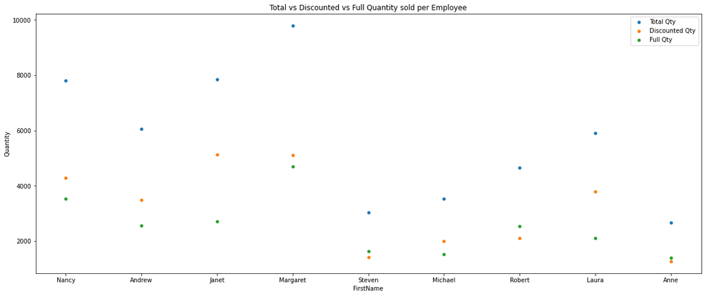

```python
# Let's import below libraries to display plots.
import seaborn as sns
import matplotlib.pyplot as plt


fig, ax = plt.subplots()
fig.set_figheight(8)
fig.set_figwidth(20)

sizes = np.array([20,50,100,200,500,1000,60,90,10,300,600,800,75])
sns.scatterplot(data=emp_total_qty, x="FirstName", y="Quantity", label='Total Qty', sizes=sizes, ax=ax)
sns.scatterplot(data=emp_disc_qty, x="FirstName", y="Quantity", label='Discounted Qty', sizes=sizes, ax=ax)
sns.scatterplot(data=emp_full_qty, x="FirstName", y="Quantity", label='Full Qty', sizes=sizes, ax=ax)

plt.title("Total vs Discounted vs Full Quantity sold per Employee")
plt.legend()
# show the graph
plt.show()
```

## Which Products are Sold?

The query below gathers data from the Order Details, Orders, Employees, Products, and Categories tables to explore the sales history of each employee.

```python
productSold = pd.read_sql(firstCall, con)
productSold = productSold.drop(productSold['Quantity'])
productSold
```

|  | OrderID | ProductID | Quantity | ProductName | CategoryID | CategoryName | EmployeeID | FirstName | LastName | Title |
| --- | --- | --- | --- | --- | --- | --- | --- | --- | --- | --- |
| 0 | 10248 | 11 | 12 | Queso Cabrales | 4 | Dairy Products | 5 | Steven | Buchanan | Sales Manager |
| 17 | 10254 | 24 | 15 | Guaraná Fantástica | 1 | Beverages | 5 | Steven | Buchanan | Sales Manager |
| 19 | 10254 | 74 | 21 | Longlife Tofu | 7 | Produce | 5 | Steven | Buchanan | Sales Manager |
| 23 | 10255 | 59 | 30 | Raclette Courdavault | 4 | Dairy Products | 9 | Anne | Dodsworth | Sales Representative |
| 26 | 10257 | 27 | 25 | Schoggi Schokolade | 3 | Confections | 4 | Margaret | Peacock | Sales Representative |
| ... | ... | ... | ... | ... | ... | ... | ... | ... | ... | ... |
| 2150 | 11077 | 64 | 2 | Wimmers gute Semmelknödel | 5 | Grains/Cereals | 1 | Nancy | Davolio | Sales Representative |
| 2151 | 11077 | 66 | 1 | Louisiana Hot Spiced Okra | 2 | Condiments | 1 | Nancy | Davolio | Sales Representative |
| 2152 | 11077 | 73 | 2 | Röd Kaviar | 8 | Seafood | 1 | Nancy | Davolio | Sales Representative |
| 2153 | 11077 | 75 | 4 | Rhönbräu Klosterbier | 1 | Beverages | 1 | Nancy | Davolio | Sales Representative |
| 2154 | 11077 | 77 | 2 | Original Frankfurter grüne Soße | 2 | Condiments | 1 | Nancy | Davolio | Sales Representative |

2100 rows × 10 columns

First, we'll find each employee's most popular product. Note that this is computed using how frequently the product is ordered, not the quantity ordered.

```python
from collections import Counter

def most_common_item(List):
    Occurence_count = Counter(List) #counts occurrence of each sold item
    return Occurence_count.most_common(1)[0][0] #returns most common
```

```python
#apply the above function to each employee

buchanan = productSold[productSold['LastName'] == 'Buchanan']
buc = most_common_item(buchanan.ProductName)

callahan = productSold[productSold['LastName'] == 'Callahan']
cal = most_common_item(callahan.ProductName)

davolio = productSold[productSold['LastName'] == 'Davolio']
dav = most_common_item(davolio.ProductName)

dodsworth = productSold[productSold['LastName'] == 'Dodsworth']
dod = most_common_item(dodsworth.ProductName)

fuller = productSold[productSold['LastName'] == 'Fuller']
ful = most_common_item(fuller.ProductName)

king = productSold[productSold['LastName'] == 'King']
kin = most_common_item(king.ProductName)

leverling = productSold[productSold['LastName'] == 'Leverling']
lev = most_common_item(leverling.ProductName)

peacock = productSold[productSold['LastName'] == 'Peacock']
pea = most_common_item(peacock.ProductName)

suyama = productSold[productSold['LastName'] == 'Suyama']
suy = most_common_item(suyama.ProductName)

keys = list(productSold.LastName.unique())
values = [buc, suy, pea, lev, dod, dav, cal, ful, kin]
comprod = pd.DataFrame(zip(keys,values), columns = ["Employee", "Most Common Product Sold"])
comprod
```

|  | Employee | Most Common Product Sold |
| --- | --- | --- |
| 0 | Buchanan | Mozzarella di Giovanni |
| 1 | Dodsworth | Gorgonzola Telino |
| 2 | Peacock | Gnocchi di nonna Alice |
| 3 | Davolio | Gumbär Gummibärchen |
| 4 | Callahan | Raclette Courdavault |
| 5 | Suyama | Flotemysost |
| 6 | Leverling | Steeleye Stout |
| 7 | Fuller | Singaporean Hokkien Fried Mee |
| 8 | King | Sasquatch Ale |

Next, we'll look at the distribution of orders over each product category across employees. Let's first create a table with this information:

```python
catbyemp = pd.crosstab(productSold.LastName, productSold.CategoryName)
catbyemp
```

| CategoryName LastName | Beverages | Condiments | Confections | Dairy Products | Grains/Cereals | Meat/Poultry | Produce | Seafood |
| --- | --- | --- | --- | --- | --- | --- | --- | --- |
| Buchanan | 21 | 8 | 15 | 30 | 8 | 10 | 10 | 12 |
| Callahan | 51 | 28 | 42 | 33 | 25 | 23 | 16 | 37 |
| Davolio | 58 | 30 | 56 | 65 | 21 | 25 | 28 | 58 |
| Dodsworth | 22 | 15 | 12 | 25 | 3 | 6 | 2 | 17 |
| Fuller | 44 | 24 | 34 | 36 | 27 | 24 | 12 | 36 |
| King | 36 | 20 | 27 | 31 | 14 | 15 | 9 | 23 |
| Leverling | 62 | 25 | 51 | 49 | 35 | 20 | 15 | 53 |
| Peacock | 72 | 43 | 68 | 52 | 44 | 35 | 24 | 66 |
| Suyama | 29 | 15 | 22 | 37 | 12 | 10 | 17 | 20 |

Below we can visually represent the data from the table above using a bar plot. Some observations to note are that Peacock has the most sales overall, and their most frequently ordered products are from the Beverages category. The most popular categories for each employee are summarized in the table below:

| Employee | Category |
| --- | --- |
| Buchanan | Dairy Products |
| Callahan | Beverages |
| Davolio | Dairy Products |
| Dodsworth | Dairy Products |
| Fuller | Beverages |
| King | Beverages |
| Leverling | Beverages |
| Peackock | Beverages |
| Suyama | Dairy Products |

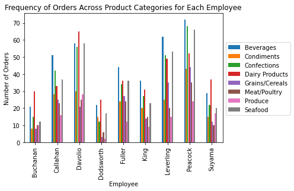

```python
catbyemp.plot.bar() #plot types of products sold by each employee in bar graph
plt.legend(loc = 'upper left', bbox_to_anchor = (1, 0.8)) #adjust position of legend
plt.xlabel("Employee")
plt.ylabel("Number of Orders")
plt.title("Frequency of Orders Across Product Categories for Each Employee")
```

Clearly, the product categories with the most orders are Beverages and Dairy Products. The number of employees with either as their most popular category is almost split evenly. It should also be noted that the employees with the best sales records are Peacock, Leverling, and Davolio.

## Performance Across the Years

Now we'll examine employee performance across the years. This is best examined by looking at total revenue from each employee during each year, so we'll pull data from the Order Details, Orders, and Employees tables.

```python
second_call = '''
              SELECT d.OrderID, d.UnitPrice, d.Quantity, d.Discount, o.EmployeeID, e.LastName, o.OrderDate
                     FROM 'Order Details' as d
                  INNER JOIN Orders as o ON o.OrderId = d.OrderID
                  INNER JOIN Employees as e ON e.EmployeeID = o.EmployeeID
              '''

sales = pd.read_sql(second_call, con)
sales
```

|  | OrderID | UnitPrice | Quantity | Discount | EmployeeID | LastName | OrderDate |
| --- | --- | --- | --- | --- | --- | --- | --- |
| 0 | 10248 | 14.00 | 12 | 0.00 | 5 | Buchanan | 1996-07-04 00:00:00.000 |
| 1 | 10248 | 9.80 | 10 | 0.00 | 5 | Buchanan | 1996-07-04 00:00:00.000 |
| 2 | 10248 | 34.80 | 5 | 0.00 | 5 | Buchanan | 1996-07-04 00:00:00.000 |
| 3 | 10249 | 18.60 | 9 | 0.00 | 6 | Suyama | 1996-07-05 00:00:00.000 |
| 4 | 10249 | 42.40 | 40 | 0.00 | 6 | Suyama | 1996-07-05 00:00:00.000 |
| ... | ... | ... | ... | ... | ... | ... | ... |
| 2150 | 11077 | 33.25 | 2 | 0.03 | 1 | Davolio | 1998-05-06 00:00:00.000 |
| 2151 | 11077 | 17.00 | 1 | 0.00 | 1 | Davolio | 1998-05-06 00:00:00.000 |
| 2152 | 11077 | 15.00 | 2 | 0.01 | 1 | Davolio | 1998-05-06 00:00:00.000 |
| 2153 | 11077 | 7.75 | 4 | 0.00 | 1 | Davolio | 1998-05-06 00:00:00.000 |
| 2154 | 11077 | 13.00 | 2 | 0.00 | 1 | Davolio | 1998-05-06 00:00:00.000 |

2155 rows × 7 columns

Now we need to create a couple of new variables to find the exact information we're looking for. First, we'll use the `OrderDate` variable and extract only the first four characters of the string to create an `OrderYear` variable. Then we'll define a function that uses `UnitPrice`, `Quantity`, and `Discount` to calculate the sale revenue (including discount) for each order. We'll call this variable `OrderRevenue`. Then we'll calculate the without discount revenue and call this `TotalRevenue`.

```python
sales['OrderYear'] = sales.OrderDate.str[:4] #only read first four chars of OrderDate variable to make year

def tot_rev(unitprice, quantity, discount): #calculate discounted total
    subtot = unitprice * quantity
    disc = subtot * discount
    tot = subtot - disc
    return tot

sales['OrderRevenue'] = tot_rev(sales.UnitPrice, sales.Quantity, sales.Discount) #apply discounted total func
sales['TotalRevenue'] = sales.UnitPrice * sales.Quantity #caluculate non-discounted total
sales
```

|  | OrderID | UnitPrice | Quantity | Discount | EmployeeID | LastName | OrderDate | OrderYear | OrderRevenue | TotalRevenue |
| --- | --- | --- | --- | --- | --- | --- | --- | --- | --- | --- |
| 0 | 10248 | 14.00 | 12 | 0.00 | 5 | Buchanan | 1996-07-04 00:00:00.000 | 1996 | 168.000 | 168.0 |
| 1 | 10248 | 9.80 | 10 | 0.00 | 5 | Buchanan | 1996-07-04 00:00:00.000 | 1996 | 98.000 | 98.0 |
| 2 | 10248 | 34.80 | 5 | 0.00 | 5 | Buchanan | 1996-07-04 00:00:00.000 | 1996 | 174.000 | 174.0 |
| 3 | 10249 | 18.60 | 9 | 0.00 | 6 | Suyama | 1996-07-05 00:00:00.000 | 1996 | 167.400 | 167.4 |
| 4 | 10249 | 42.40 | 40 | 0.00 | 6 | Suyama | 1996-07-05 00:00:00.000 | 1996 | 1696.000 | 1696.0 |
| ... | ... | ... | ... | ... | ... | ... | ... | ... | ... | ... |
| 2150 | 11077 | 33.25 | 2 | 0.03 | 1 | Davolio | 1998-05-06 00:00:00.000 | 1998 | 64.505 | 66.5 |
| 2151 | 11077 | 17.00 | 1 | 0.00 | 1 | Davolio | 1998-05-06 00:00:00.000 | 1998 | 17.000 | 17.0 |
| 2152 | 11077 | 15.00 | 2 | 0.01 | 1 | Davolio | 1998-05-06 00:00:00.000 | 1998 | 29.700 | 30.0 |
| 2153 | 11077 | 7.75 | 4 | 0.00 | 1 | Davolio | 1998-05-06 00:00:00.000 | 1998 | 31.000 | 31.0 |
| 2154 | 11077 | 13.00 | 2 | 0.00 | 1 | Davolio | 1998-05-06 00:00:00.000 | 1998 | 26.000 | 26.0 |

2155 rows × 10 columns

```python
timerev = pd.pivot_table(sales, values = ["TotalRevenue"], index = ["LastName"], aggfunc = ["sum"])
timerev
```

| LastName | sum TotalRevenue |
| --- | --- |
| Buchanan | 75567.75 |
| Callahan | 133301.03 |
| Davolio | 202143.71 |
| Dodsworth | 82964.00 |
| Fuller | 177749.26 |
| King | 141295.99 |
| Leverling | 213051.30 |
| Peacock | 250187.45 |
| Suyama | 78198.10 |

Using the new variables computed above, we can create a table listing the revenue for each employee for each of the three years.

```python
#sum totalrevenue over year and last name
timerev = pd.pivot_table(sales, values = ["TotalRevenue"], index = ["LastName", "OrderYear"], aggfunc = ["sum"])
timerev
```

| LastName | OrderYear | sum TotalRevenue |
| --- | --- | --- |
| Buchanan | 1996 | 21965.20 |
|  | 1997 | 32595.05 |
|  | 1998 | 21007.50 |
| Callahan | 1996 | 23161.40 |
|  | 1997 | 59776.52 |
|  | 1998 | 50363.11 |
| Davolio | 1996 | 38789.00 |
|  | 1997 | 97533.58 |
|  | 1998 | 65821.13 |
| Dodsworth | 1996 | 11365.70 |
|  | 1997 | 29577.55 |
|  | 1998 | 42020.75 |
| Fuller | 1996 | 22834.70 |
|  | 1997 | 74958.60 |
|  | 1998 | 79955.96 |
| King | 1996 | 18104.80 |
|  | 1997 | 66689.14 |
|  | 1998 | 56502.05 |
| Leverling | 1996 | 19231.80 |
|  | 1997 | 111788.61 |
|  | 1998 | 82030.89 |
| Peacock | 1996 | 53114.80 |
|  | 1997 | 139477.70 |
|  | 1998 | 57594.95 |
| Suyama | 1996 | 17731.10 |
|  | 1997 | 45992.00 |
|  | 1998 | 14475.00 |

Here we are restructuring the table to prepare it for graphical display. For ease of use, let's use each employee name as a column in our new data table.

```python
timerev.columns.name = None #get rid of 'sum' level in naming hierarchy
timerev = timerev.reset_index() #reset index
```

```python
timerev.columns = ["LastName", "OrderYear", "RevenueSum"]  #rename columns
timerev_new = timerev.pivot(index = "OrderYear", columns = ["LastName"], values = "RevenueSum") #create new table with last names as columns
timerev_new
```

| LastName OrderYear | Buchanan | Callahan | Davolio | Dodsworth | Fuller | King | Leverling | Peacock | Suyama |
| --- | --- | --- | --- | --- | --- | --- | --- | --- | --- |
| 1996 | 21965.20 | 23161.40 | 38789.00 | 11365.70 | 22834.70 | 18104.80 | 19231.80 | 53114.80 | 17731.1 |
| 1997 | 32595.05 | 59776.52 | 97533.58 | 29577.55 | 74958.60 | 66689.14 | 111788.61 | 139477.70 | 45992.0 |
| 1998 | 21007.50 | 50363.11 | 65821.13 | 42020.75 | 79955.96 | 56502.05 | 82030.89 | 57594.95 | 14475.0 |

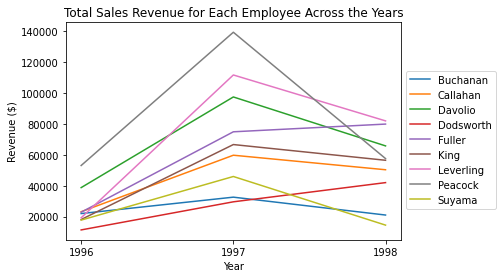

```python
Year = ["1996", "1997", "1998"] #specify years

#plot line for each employee in layers on graph
plt.plot(Year, timerev_new.Buchanan, label = "Buchanan")
plt.plot(Year, timerev_new.Callahan, label = "Callahan")
plt.plot(Year, timerev_new.Davolio, label = "Davolio")
plt.plot(Year, timerev_new.Dodsworth, label = "Dodsworth")
plt.plot(Year, timerev_new.Fuller, label = "Fuller")
plt.plot(Year, timerev_new.King, label = "King")
plt.plot(Year, timerev_new.Leverling, label = "Leverling")
plt.plot(Year, timerev_new.Peacock, label = "Peacock")
plt.plot(Year, timerev_new.Suyama, label = "Suyama")

plt.legend(bbox_to_anchor = (1, 0.8)) #adjust legend position
plt.xlabel("Year")
plt.ylabel("Revenue ($)")
plt.title("Total Sales Revenue for Each Employee Across the Years")
```

## Regional Performance

The steps are:

Merge the data according to the CustomerID, OrderID and EmployeeID.

Perform the data analysis on the total sale and quantity by each regions

```python
#Extract data for region
sql='''
select d.LastName,a.CustomerID,a.Region,b.OrderID,b.EmployeeID,c.ProductID,c.Quantity,c.UnitPrice, c.Quantity*c.UnitPrice as TotalSale from Customers as a
left join Orders as b on a.CustomerID=b.CustomerID
left join 'Order Details' as c on c.OrderID=b.OrderID
left join Employees as d on d.EmployeeID=b.EmployeeID;
'''
Region=pd.read_sql( sql, con)
Region
```

|  | LastName | CustomerID | Region | OrderID | EmployeeID | ProductID | Quantity | UnitPrice | TotalSale |
| --- | --- | --- | --- | --- | --- | --- | --- | --- | --- |
| 0 | Davolio | ALFKI | None | 10835.0 | 1.0 | 59.0 | 15.0 | 55.00 | 825.0 |
| 1 | Davolio | ALFKI | None | 10835.0 | 1.0 | 77.0 | 2.0 | 13.00 | 26.0 |
| 2 | Davolio | ALFKI | None | 10952.0 | 1.0 | 6.0 | 16.0 | 25.00 | 400.0 |
| 3 | Davolio | ALFKI | None | 10952.0 | 1.0 | 28.0 | 2.0 | 45.60 | 91.2 |
| 4 | Leverling | ALFKI | None | 11011.0 | 3.0 | 58.0 | 40.0 | 13.25 | 530.0 |
| ... | ... | ... | ... | ... | ... | ... | ... | ... | ... |
| 2154 | Suyama | WOLZA | None | 10611.0 | 6.0 | 60.0 | 15.0 | 34.00 | 510.0 |
| 2155 | Callahan | WOLZA | None | 10998.0 | 8.0 | 24.0 | 12.0 | 4.50 | 54.0 |
| 2156 | Callahan | WOLZA | None | 10998.0 | 8.0 | 61.0 | 7.0 | 28.50 | 199.5 |
| 2157 | Callahan | WOLZA | None | 10998.0 | 8.0 | 74.0 | 20.0 | 10.00 | 200.0 |
| 2158 | Callahan | WOLZA | None | 10998.0 | 8.0 | 75.0 | 30.0 | 7.75 | 232.5 |

2159 rows × 9 columns

```python
#Check the total sale and qty by employee and region
Region.groupby(["LastName","Region"])[["Quantity","TotalSale"]].sum()
```

| LastName | Region | Quantity | TotalSale |
| --- | --- | --- | --- |
| Buchanan | ID | 524.0 | 13868.10 |
|  | Lara | 98.0 | 3251.50 |
|  | NM | 118.0 | 1607.00 |
|  | Nueva Esparta | 107.0 | 1902.10 |
|  | RJ | 147.0 | 3865.00 |
| ... | ... | ... | ... |
| Suyama | RJ | 67.0 | 946.25 |
|  | SP | 262.0 | 6054.25 |
|  | TÃ¡chira | 106.0 | 2333.20 |
|  | WA | 9.0 | 237.90 |
|  | WY | 24.0 | 48.00 |

120 rows × 2 columns

```python
#Check the total sale and qty only by employee
Region.groupby(["LastName"])[["Quantity","TotalSale"]].sum()
```

| LastName | Quantity | TotalSale |
| --- | --- | --- |
| Buchanan | 3036.0 | 75567.75 |
| Callahan | 5913.0 | 133301.03 |
| Davolio | 7812.0 | 202143.71 |
| Dodsworth | 2670.0 | 82964.00 |
| Fuller | 6055.0 | 177749.26 |
| King | 4654.0 | 141295.99 |
| Leverling | 7852.0 | 213051.30 |
| Peacock | 9798.0 | 250187.45 |
| Suyama | 3527.0 | 78198.10 |

```python
#Check the total sale and qty only by region
Plt_Region=Region.groupby(["Region"])[["Quantity","TotalSale"]].sum()
Plt_Region
```

| Region | Quantity | TotalSale |
| --- | --- | --- |
| AK | 603.0 | 16325.15 |
| BC | 1018.0 | 23130.20 |
| CA | 181.0 | 3490.02 |
| Co. Cork | 1684.0 | 57317.39 |
| DF | 34.0 | 1488.70 |
| ID | 4958.0 | 115673.39 |
| Isle of Wight | 295.0 | 6146.30 |
| Lara | 836.0 | 17825.06 |
| MT | 59.0 | 1947.24 |
| NM | 1383.0 | 52245.90 |
| Nueva Esparta | 970.0 | 17889.55 |
| OR | 647.0 | 30393.93 |
| Québec | 966.0 | 32203.90 |
| RJ | 1893.0 | 53999.18 |
| SP | 2354.0 | 60969.30 |
| Táchira | 1096.0 | 23611.58 |
| WA | 1172.0 | 31001.65 |
| WY | 327.0 | 12489.70 |

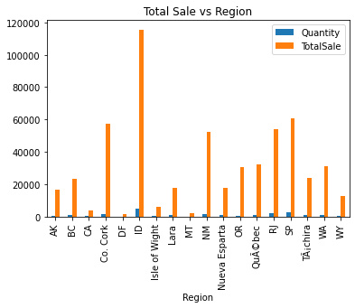

```python
#Plot total sale and qty only by region

Plt_Region.plot.bar(stacked=False)
plt.title("Total Sale vs Region")
plt.show()
plt.close()
```

## Strengths and Weaknesses of Each Employee

The step is to review all tables and plots. We also check the employee backgrounds to make fair suggestions and evaluations.

```python
#Take background to check the employee analysis
sql='''
select distinct EmployeeID,LastName,FirstName,Title,Notes from Employees;
'''
Emp=pd.read_sql(sql,con)
Emy_Sug={}
for i in range(len(list(Emp['EmployeeID']))):
    print(Emp.loc[i,"Title"]," / ",Emp.loc[i,"FirstName"],Emp.loc[i,"LastName"]," : ",Emp.loc[i,"Notes"],"\n")
```

```
Sales Representative  /  Nancy Davolio  :  Education includes a BA in psychology from Colorado State University in 1970.  She also completed "The Art of the Cold Call."  Nancy is a member of Toastmasters International.

Vice President, Sales  /  Andrew Fuller  :  Andrew received his BTS commercial in 1974 and a Ph.D. in international marketing from the University of Dallas in 1981.  He is fluent in French and Italian and reads German.  He joined the company as a sales representative, was promoted to sales manager i…

Sales Representative  /  Janet Leverling  :  Janet has a BS degree in chemistry from Boston College (1984).  She has also completed a certificate program in food retailing management.  Janet was hired as a sales associate in 1991 and promoted to sales representative in February 1992.

Sales Representative  /  Margaret Peacock  :  Margaret holds a BA in English literature from Concordia College (1958) and an MA from the American Institute of Culinary Arts (1966).  She was assigned to the London office temporarily from July through November 1992.

Sales Manager  /  Steven Buchanan  :  Steven Buchanan graduated from St. Andrews University, Scotland, with a BSC degree in 1976.  Upon joining the company as a sales representative in 1992, he spent 6 months in an orientation program at the Seattle office and then returned to his permanent post in …

Sales Representative  /  Michael Suyama  :  Michael is a graduate of Sussex University (MA, economics, 1983) and the University of California at Los Angeles (MBA, marketing, 1986).  He has also taken the courses "Multi-Cultural Selling" and "Time Management for the Sales Professional."  He is fluent…

Sales Representative  /  Robert King  :  Robert King served in the Peace Corps and traveled extensively before completing his degree in English at the University of Michigan in 1992, the year he joined the company.  After completing a course entitled "Selling in Europe," he was transferred to the Lo…

Inside Sales Coordinator  /  Laura Callahan  :  Laura received a BA in psychology from the University of Washington.  She has also completed a course in business French.  She reads and writes French.

Sales Representative  /  Anne Dodsworth  :  Anne has a BA degree in English from St. Lawrence College.  She is fluent in French and German.
```

## The employees analysis is based on the plot and table we had created and employee note. The evaluation for employees are following:

Janet Leverling : Janet has above selling performance cross all categoies of products. She kept learning food retailing management while she was working. Thus, she is above average on all food products. She is also top seller in 1998.

Margaret Peacock : Margaret is the most total sold record cross all products among employees. If he could remain this performance, he will be promoted.

Steven Buchanan : Steven is with performance much below average. He needs to improve all skills and/or return school for advanced educatio, n

Michael Suyama : Michael is with great edcuation and mulitple languages. However, he is bottom performance in 1998. He needs to work harder to match what he is supposed to perform

Robert King : Robert is about the average among all employees. He has a lot of room to improve overall.

Laura Callahan : Laura is about the average among all employees. She could go for advanced education for potential growth.

Anne Dodsworth : Anne is with bottom selling performance overall. However, she is getting better by each year. She could focus on meat, grains and produce for improvement.

For the employees with title as Sales Representative, they are Dodsworth, King, Suyama, Peacock, Leverling and Davolio. Among of them, Dodsworth needs to work harder and Peacock is top employee

For the employees with title as Inside Sales Coordinator, Callahan is only employee with that title. It is hard to compare to other employee with different title.

For the employees with title as Sales Manager, Buchanan is only employee with that title. It is hard to compare to other employee with different title.

For the employees with title as Vice President, Fuller is only employee with that title. It is hard to compare to other employee with different title.